# Assignment_9

### Model Exploration and Interpretation to Predict Graduate School Admission

First, setting up the packages I will use.

```r
library(tidyverse)
library(modelr)
library(easystats)
library(MASS)
library(viridis)
```

Taking a look at the data:

```r
df <- read.csv("../Data/GradSchool_Admissions.csv")
glimpse(df)
```

```
## Rows: 400
## Columns: 4
## $ admit <int> 0, 1, 1, 1, 0, 1, 1, 0, 1, 0, 0, 0, 1, 0, 1, 0, 0, 0, 0, 1, 0, 1…
## $ gre   <int> 380, 660, 800, 640, 520, 760, 560, 400, 540, 700, 800, 440, 760,…
## $ gpa   <dbl> 3.61, 3.67, 4.00, 3.19, 2.93, 3.00, 2.98, 3.08, 3.39, 3.92, 4.00…
## $ rank  <int> 3, 3, 1, 4, 4, 2, 1, 2, 3, 2, 4, 1, 1, 2, 1, 3, 4, 3, 2, 1, 3, 2…
```

Here is the distribution of GRE scores and grouped GPAs for the sample group.

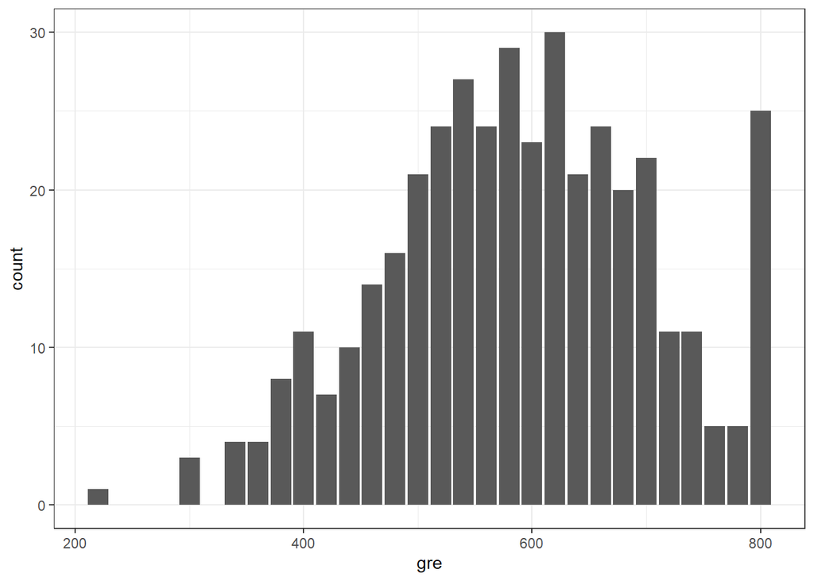

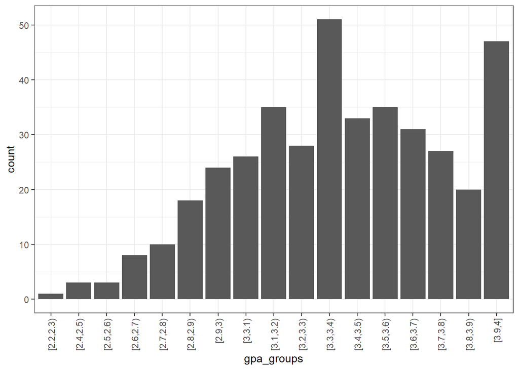

```r
df %>%
  ggplot(aes(x=gre)) +
  geom_bar() +
  theme_bw()
gpas <- df$gpa
bins <- seq(1.0, 4.0, by = 0.1)
gpa_groups <- cut(gpas, breaks = bins, include.lowest = TRUE, right = FALSE)
df %>%
  ggplot(aes(x=gpa_groups)) +
  geom_bar() +
  theme_bw() +
  theme(axis.text.x = element_text(angle = 90, vjust = 0.5, hjust=1))
```

A plot of all the data:

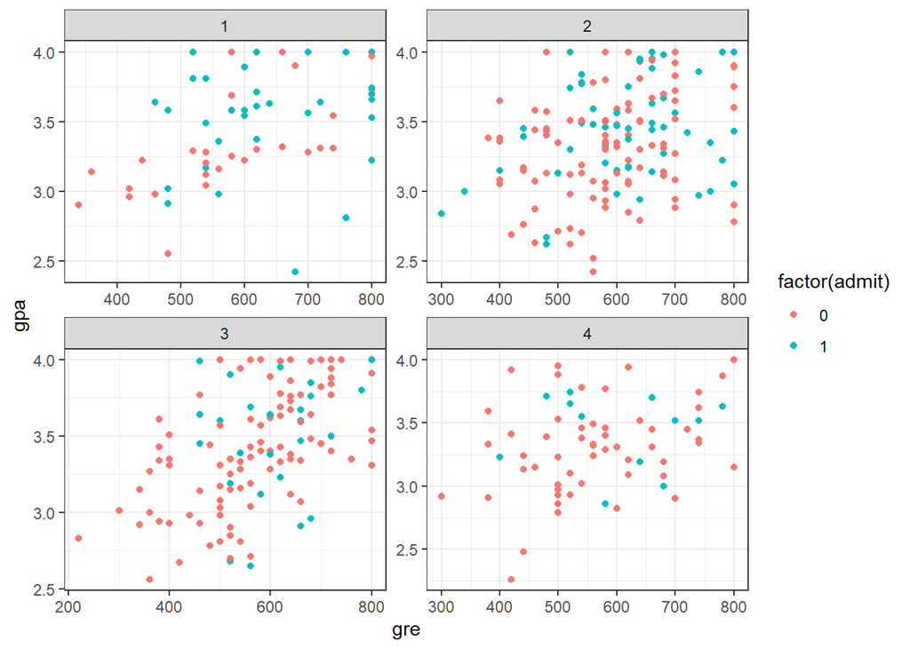

```r
df %>%
  ggplot(aes(x=gre,y=gpa,color=factor(admit))) +
  geom_point() +
  facet_wrap(~rank,scales = 'free') +
  theme_bw()
```

Acceptance rates look scattered. Let’s see if there are meaningful correlations to be aware of.

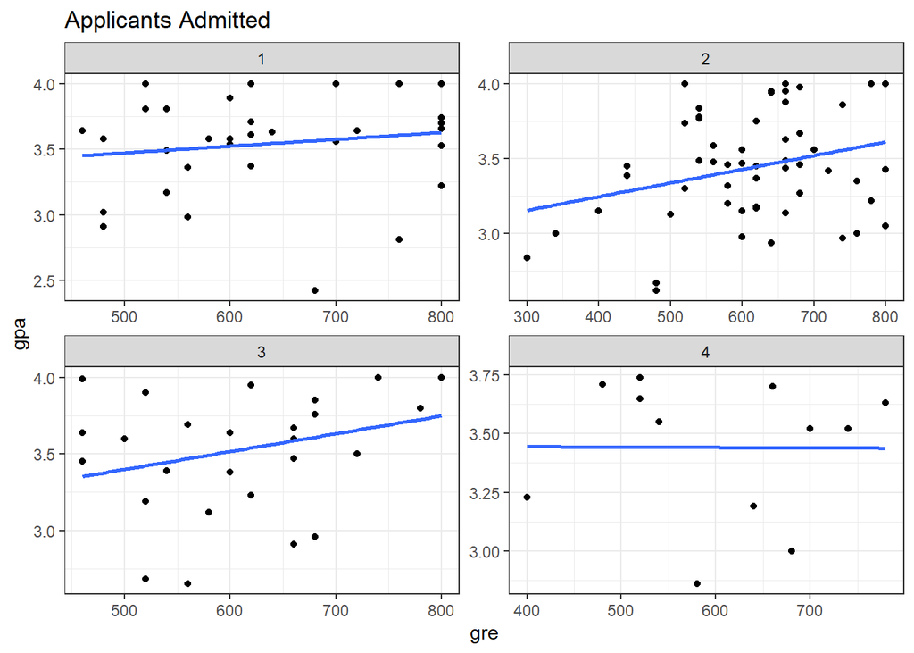

```r
df %>%
  filter(admit == 1) %>%
  ggplot(aes(x=gre,y=gpa)) +
  geom_point() +
  facet_wrap(~rank,scales = 'free') +
  geom_smooth(method='lm',se=FALSE) +
  ggtitle("Applicants Admitted") +
  theme_bw()
```

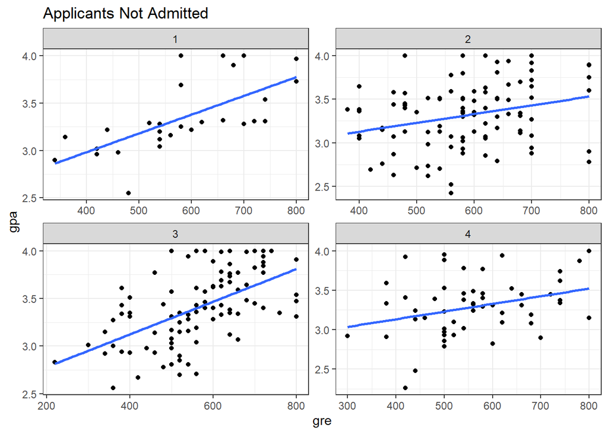

```r
df %>%
  filter(admit == 0) %>%
  ggplot(aes(x=gre,y=gpa)) +
  geom_point() +
  facet_wrap(~rank,scales = 'free') +
  geom_smooth(method='lm',se=FALSE) +
  ggtitle("Applicants Not Admitted") +
  theme_bw()
```

Looks like there is a positive correlation between GPA and GRE scores, but this is true whether or not the student is admitted, so it won’t help much for predicting admittance.

We can get a better idea of how GPA influences admission.

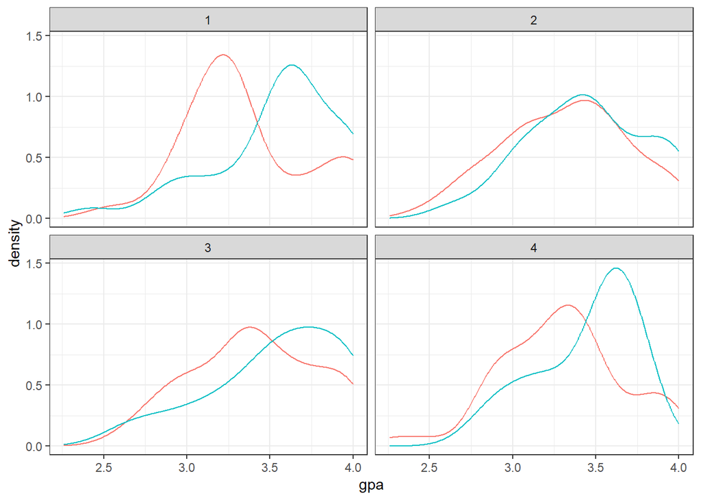

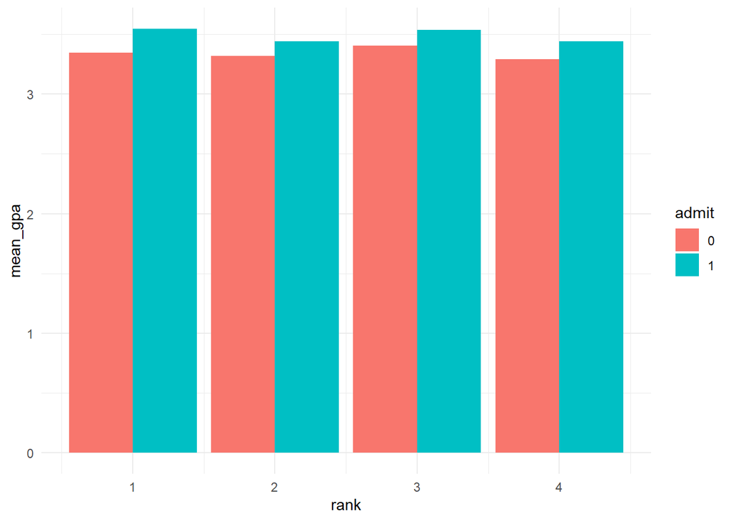

```r
df$admit <- as.character(df$admit)
df %>%
  ggplot(aes(x=gpa,color=admit)) +
  geom_density() +
  facet_wrap(~rank) +
  theme_bw() +
  theme(legend.position = 'none')
df %>%
  group_by(rank,admit) %>%
  summarize(mean_gpa = mean(gpa)) %>%
  ggplot(aes(x=rank,y=mean_gpa)) +
  geom_col(aes(fill=admit),position = 'dodge') +
  theme_minimal()
```

```r
df %>%
  group_by(rank,admit) %>%
  summarize(mean_gpa = mean(gpa))
```

```
## # A tibble: 8 × 3
## # Groups:   rank [4]
##    rank admit mean_gpa
##   <int> <chr>    <dbl>
## 1     1 0         3.35
## 2     1 1         3.54
## 3     2 0         3.32
## 4     2 1         3.44
## 5     3 0         3.40
## 6     3 1         3.53
## 7     4 0         3.29
## 8     4 1         3.44
```

GPA is higher on average for students that were admitted

As are GRE Scores.

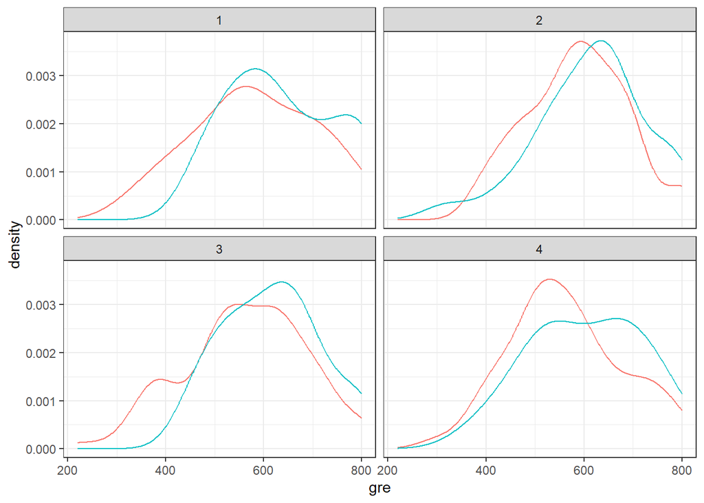

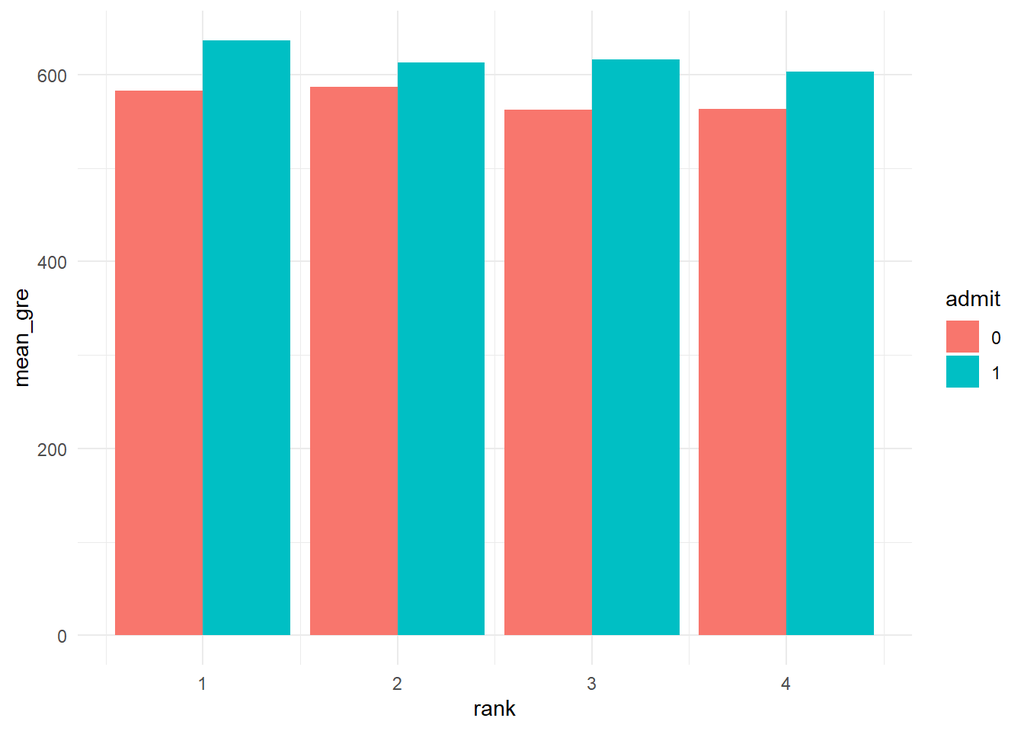

```r
df %>%
  ggplot(aes(x=gre,color=admit)) +
  geom_density() +
  facet_wrap(~rank) +
  theme_bw() +
  theme(legend.position = 'none')
df %>%
  group_by(rank,admit) %>%
  summarize(mean_gre = mean(gre)) %>%
  ggplot(aes(x=rank,y=mean_gre)) +
  geom_col(aes(fill=admit),position = 'dodge') +
  theme_minimal()
```

```r
df %>%
  group_by(rank,admit) %>%
  summarize(mean_gre = mean(gre))
```

```
## # A tibble: 8 × 3
## # Groups:   rank [4]
##    rank admit mean_gre
##   <int> <chr>    <dbl>
## 1     1 0         583.
## 2     1 1         636.
## 3     2 0         587.
## 4     2 1         613.
## 5     3 0         562.
## 6     3 1         616.
## 7     4 0         563.
## 8     4 1         603.
```

Now that we have a better idea of what is going on with our data, we can start preparing models.

```r
names(df)
```

```
## [1] "admit" "gre"   "gpa"   "rank"
```

```r
df$admit <- as.integer(df$admit)
mod1 <- glm(data=df,
            formula=admit ~ gpa + gre,
            family='binomial')
mod2 <- glm(data=df,
            formula=admit ~ gpa + gre + rank,
            family='binomial')
mod3 <- glm(data=df,
            formula=admit ~ gpa * gre * rank,
            family='binomial')
mod4 <- glm(data=df,
            formula=admit ~ .^2,
            family='binomial')
mod5 <- glm(data=df,
            formula=admit ~ gpa * gre + rank,
            family= 'binomial')
mod5 <- glm(data=df,
                    formula=admit ~ gre + gpa * rank,
                    family='binomial')
```

I will use the stepAIC function to see if there is a better model to investigate.

```r
step <- stepAIC(mod3)
```

```
## Start:  AIC=472.25
## admit ~ gpa * gre * rank
##
##                Df Deviance    AIC
## - gpa:gre:rank  1   456.25 470.25
## <none>              456.25 472.25
##
## Step:  AIC=470.25
## admit ~ gpa + gre + rank + gpa:gre + gpa:rank + gre:rank
##
##            Df Deviance    AIC
## - gre:rank  1   456.34 468.34
## - gpa:rank  1   456.58 468.58
## <none>          456.25 470.25
## - gpa:gre   1   459.31 471.31
##
## Step:  AIC=468.34
## admit ~ gpa + gre + rank + gpa:gre + gpa:rank
##
##            Df Deviance    AIC
## - gpa:rank  1   456.60 466.60
## <none>          456.34 468.34
## - gpa:gre   1   459.33 469.33
##
## Step:  AIC=466.6
## admit ~ gpa + gre + rank + gpa:gre
##
##           Df Deviance    AIC
## <none>         456.60 466.60
## - gpa:gre  1   459.44 467.44
## - rank     1   477.85 485.85
```

```r
step$formula
```

```
## admit ~ gpa + gre + rank + gpa:gre
```

```r
step <- stepAIC(mod4)
```

```
## Start:  AIC=470.25
## admit ~ (gre + gpa + rank)^2
##
##            Df Deviance    AIC
## - gre:rank  1   456.34 468.34
## - gpa:rank  1   456.58 468.58
## <none>          456.25 470.25
## - gre:gpa   1   459.31 471.31
##
## Step:  AIC=468.34
## admit ~ gre + gpa + rank + gre:gpa + gpa:rank
##
##            Df Deviance    AIC
## - gpa:rank  1   456.60 466.60
## <none>          456.34 468.34
## - gre:gpa   1   459.33 469.33
##
## Step:  AIC=466.6
## admit ~ gre + gpa + rank + gre:gpa
##
##           Df Deviance    AIC
## <none>         456.60 466.60
## - gre:gpa  1   459.44 467.44
## - rank     1   477.85 485.85
```

```r
step$formula
```

```
## admit ~ gre + gpa + rank + gre:gpa
```

Both formulas suggest this is the best model. Let’s name it model 6 and compare all the models.

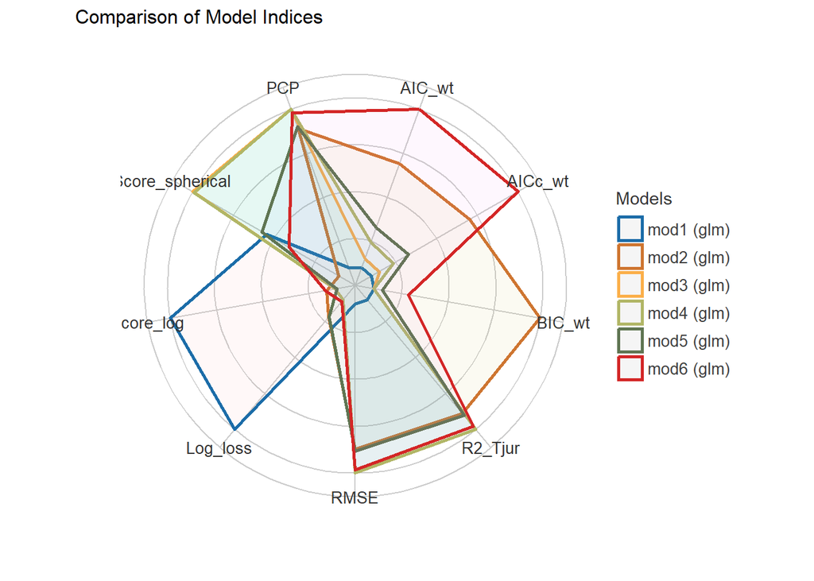

```r
mod6 <- glm(data=df,
            formula=admit ~ gre + gpa + rank + gre:gpa,
            family='binomial')
compare_performance(mod6,mod5,mod4,mod3,mod2,mod1) %>% plot
```

```r
mod6$aic
```

```
## [1] 466.5975
```

```r
mod5$aic
```

```
## [1] 469.3348
```

```r
mod4$aic
```

```
## [1] 470.2501
```

```r
mod1$aic
```

```
## [1] 486.344
```

```r
mod2$aic
```

```
## [1] 467.4418
```

```r
mod3$aic
```

```
## [1] 472.2499
```

Model 6 seems to be performing the best. It is relatively simple, so over-fitting is not a major concern for me.

Let’s add predictions from model 6 to our dataframe.

```r
df$predicted_prob <- predict(mod6, type = "response")
```

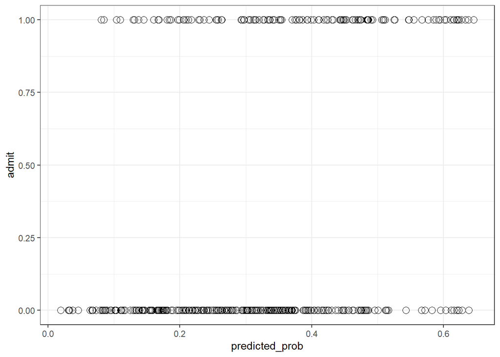

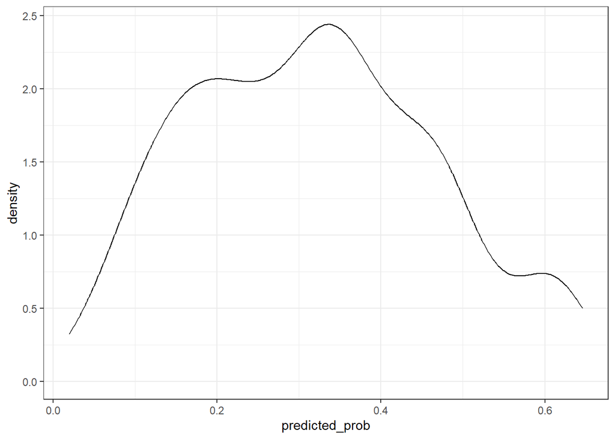

```r
df %>%
  ggplot(aes(x=predicted_prob,y=admit)) +
  geom_point(shape=1,size=3) +
  theme_bw()
df %>%
  ggplot(aes(x=predicted_prob)) +
  geom_density() +
  theme_bw()
```

Because my model is binomial, it made predictions between 0 and 1. Most often students were not admitted. My model has prediction values mostly from about 0.15 to 0.4. It would be ideal if there were clear distributions of which predictions were closer to 0 (not admitted) and which were closer to 1 (admitted).

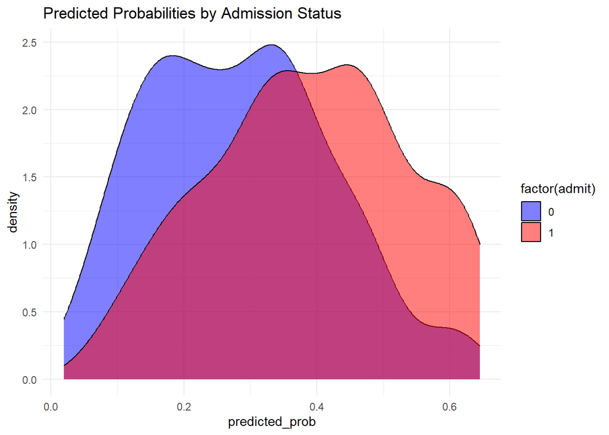

```r
ggplot(df, aes(x = predicted_prob, fill = factor(admit))) +
  geom_density(alpha = 0.5) +
  ggtitle("Predicted Probabilities by Admission Status") +
  scale_fill_manual(values = c("blue", "red")) +
  theme_minimal()
```

This plot shows that there is a relationship between lower predicted values and non-admission and higher predicted values and admission.

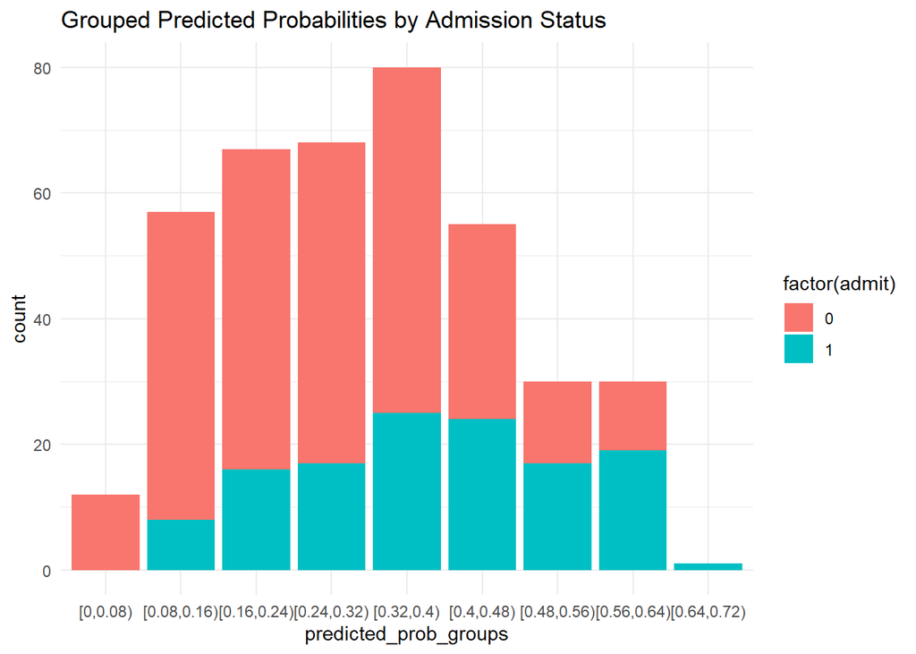

```r
bins <- seq(0, 1, by = 0.08)
predicted_prob_groups <- cut(df$predicted_prob, breaks = bins, include.lowest = TRUE, right = FALSE)
df %>%
  ggplot(aes(x=predicted_prob_groups,fill=factor(admit))) +
  geom_bar() +
  theme(axis.text.x = element_text(angle = 90, vjust = 0.5, hjust=1)) +
  ggtitle("Grouped Predicted Probabilities by Admission Status") +
  theme_minimal()
```

It looks like in the groups with higher predicted values, there is a a higher percentage of applicants who were admitted.

What if I predict that those with a predicted value of 0.44 or higher are admitted since that is about when the percentage of admitted applicants becomes higher than non-admitted applicants.

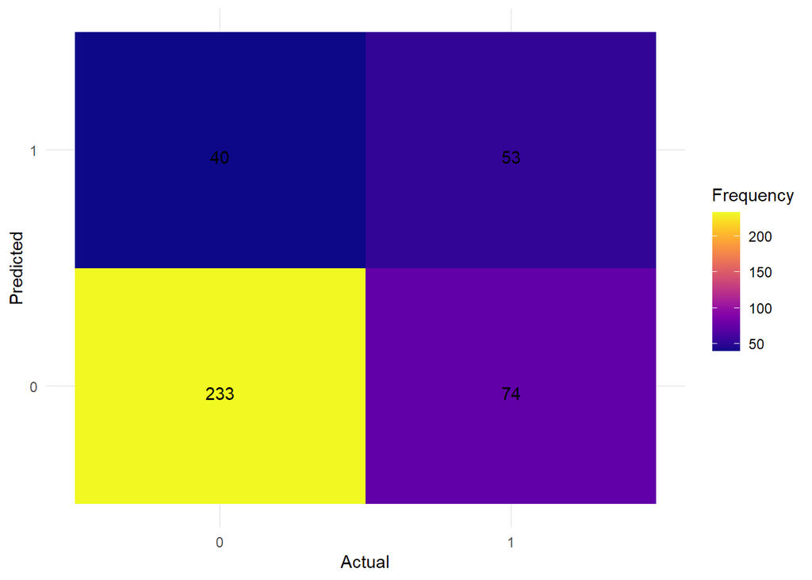

```r
df$predicted_admit <- ifelse(df$predicted_prob >= 0.44, 1, 0)
predicted <- df$predicted_admit
actual <- df$admit
conf_matrix <- table(actual, predicted)
conf_matrix_df <- as.data.frame.matrix(conf_matrix)
conf_matrix_df <- cbind(Actual = rownames(conf_matrix_df), conf_matrix_df)
conf_matrix_long <- gather(conf_matrix_df, key = "Predicted", value = "Frequency", -Actual)
ggplot(conf_matrix_long, aes(x = Actual, y = Predicted, fill = Frequency)) +
  geom_tile() +
  geom_text(aes(label = Frequency), vjust = 1) +
  scale_fill_viridis(name = "Frequency", option = "plasma") +
  labs(x = "Actual", y = "Predicted") +
  theme_minimal()
```

What if I take the prediction groups I made and create a new column in the data frame that is a percentage of how many applications in each group were admitted. And make predictions based off that percentage.

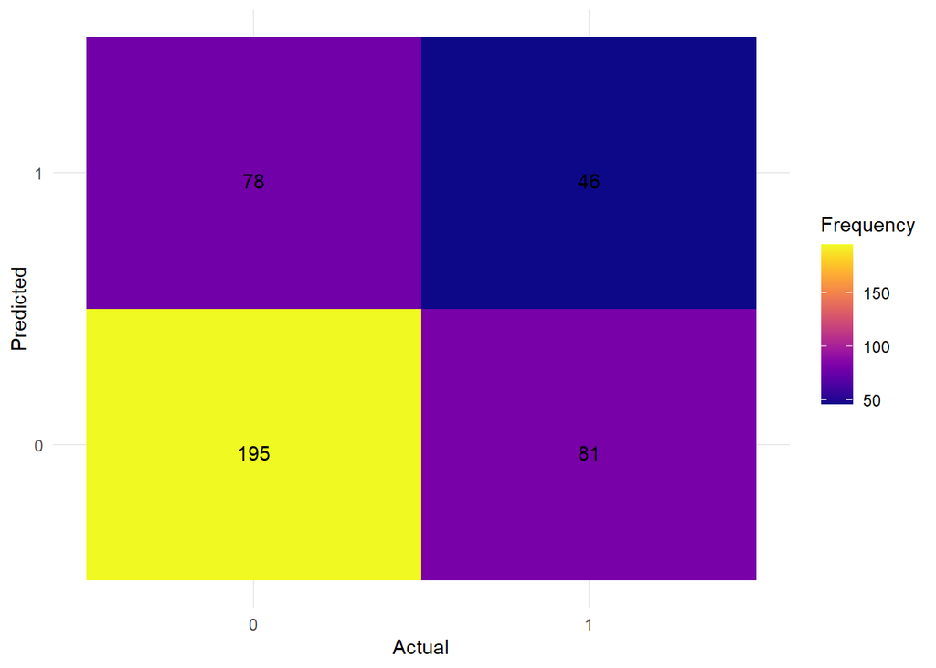

```r
subset_0.0 <- df %>%
  filter(predicted_prob >= 0.0 & predicted_prob <= 0.08)
subset_0.08 <- df %>%
  filter(predicted_prob >= 0.08 & predicted_prob <= 0.16)
subset_0.16 <- df %>%
  filter(predicted_prob >= 0.16 & predicted_prob <= 0.24)
subset_0.24 <- df %>%
  filter(predicted_prob >= 0.24 & predicted_prob <= 0.32)
subset_0.32 <- df %>%
  filter(predicted_prob >= 0.32 & predicted_prob <= 0.4)
subset_0.4 <- df %>%
  filter(predicted_prob >= 0.4 & predicted_prob <= 0.48)
subset_0.48 <- df %>%
  filter(predicted_prob >= 0.48 & predicted_prob <= 0.56)
subset_0.56 <- df %>%
  filter(predicted_prob >= 0.56 & predicted_prob <= 0.64)
subset_0.64 <- df %>%
  filter(predicted_prob >= 0.64 & predicted_prob <= 0.72)

percentage_0.0 <- subset_0.0 %>% group_by(admit) %>%
  summarize(percentage = n() / nrow(subset_0.0) * 100)
percentage_0.08 <- subset_0.08 %>% group_by(admit) %>%
  summarize(percentage = n() / nrow(subset_0.08) * 100)
percentage_0.16 <- subset_0.16 %>% group_by(admit) %>%
  summarize(percentage = n() / nrow(subset_0.16) * 100)
percentage_0.24 <- subset_0.24 %>% group_by(admit) %>%
  summarize(percentage = n() / nrow(subset_0.24) * 100)
percentage_0.32 <- subset_0.32 %>% group_by(admit) %>%
  summarize(percentage = n() / nrow(subset_0.32) * 100)
percentage_0.4 <- subset_0.4 %>% group_by(admit) %>%
  summarize(percentage = n() / nrow(subset_0.4) * 100)
percentage_0.48 <- subset_0.48 %>% group_by(admit) %>%
  summarize(percentage = n() / nrow(subset_0.48) * 100)
percentage_0.56 <- subset_0.56 %>% group_by(admit) %>%
  summarize(percentage = n() / nrow(subset_0.56) * 100)
percentage_0.64 <- subset_0.64 %>% group_by(admit) %>%
  summarize(percentage = n() / nrow(subset_0.64) * 100)

df <- df %>%
  mutate(percentage_column = case_when(
    (predicted_prob >= 0.0 & predicted_prob <= 0.08) ~ percentage_0.0$percentage[1] * 0,
    (predicted_prob > 0.08 & predicted_prob <= 0.16) ~ percentage_0.08$percentage[2] / 100,
    (predicted_prob > 0.16 & predicted_prob <= 0.24) ~ percentage_0.16$percentage[2] / 100,
    (predicted_prob > 0.24 & predicted_prob <= 0.32) ~ percentage_0.24$percentage[2] / 100,
    (predicted_prob > 0.32 & predicted_prob <= 0.4) ~ percentage_0.32$percentage[2] / 100,
    (predicted_prob > 0.4 & predicted_prob <= 0.48) ~ percentage_0.4$percentage[2] / 100,
    (predicted_prob > 0.48 & predicted_prob <= 0.56) ~ percentage_0.48$percentage[2] / 100,
    (predicted_prob > 0.56 & predicted_prob <= 0.64) ~ percentage_0.56$percentage[2] / 100,
    (predicted_prob > 0.64 & predicted_prob <= 0.72) ~ percentage_0.64$percentage[1] / 100,
    TRUE ~ NA_real_
  ))

df <- df %>%
  mutate(predicted_admit = rbinom(nrow(df), 1, percentage_column))

predicted <- df$predicted_admit
actual <- df$admit
conf_matrix <- table(actual, predicted)
conf_matrix_df <- as.data.frame.matrix(conf_matrix)
conf_matrix_df <- cbind(Actual = rownames(conf_matrix_df), conf_matrix_df)
conf_matrix_long <- gather(conf_matrix_df, key = "Predicted", value = "Frequency", -Actual)
ggplot(conf_matrix_long, aes(x = Actual, y = Predicted, fill = Frequency)) +
  geom_tile() +
  geom_text(aes(label = Frequency), vjust = 1) +
  scale_fill_viridis(name = "Frequency", option = "plasma") +
  labs(x = "Actual", y = "Predicted") +
  theme_minimal()
```

After all that work, my predictions are even worse.

I found the best way to make predictions using my model 6 is to lower the cut off point for predictions to about 0.32 to 0.35.

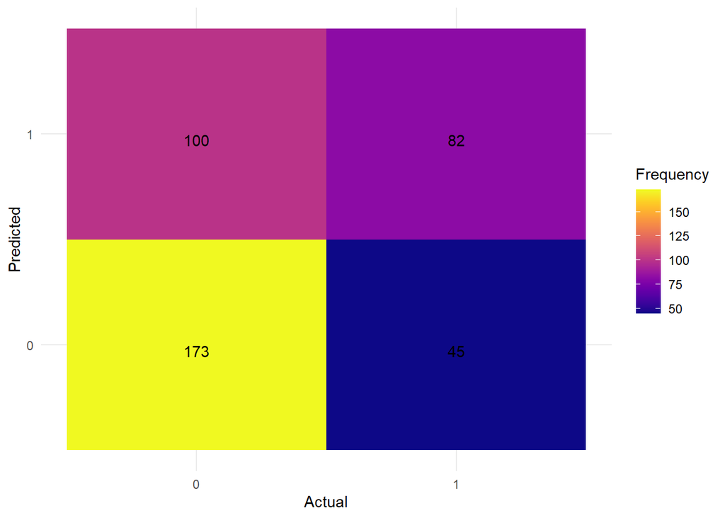

```r
df$predicted_admit <- ifelse(df$predicted_prob >= 0.335, 1, 0)

predicted <- df$predicted_admit
actual <- df$admit
conf_matrix <- table(actual, predicted)
conf_matrix_df <- as.data.frame.matrix(conf_matrix)
conf_matrix_df <- cbind(Actual = rownames(conf_matrix_df), conf_matrix_df)
conf_matrix_long <- gather(conf_matrix_df, key = "Predicted", value = "Frequency", -Actual)
ggplot(conf_matrix_long, aes(x = Actual, y = Predicted, fill = Frequency)) +
  geom_tile() +
  geom_text(aes(label = Frequency), vjust = 1) +
  scale_fill_viridis(name = "Frequency", option = "plasma") +
  labs(x = "Actual", y = "Predicted") +
  theme_minimal()
```

```r
summary(mod6)
```

```
##
## Call:
## glm(formula = admit ~ gre + gpa + rank + gre:gpa, family = "binomial",
##     data = df)
##
## Coefficients:
##               Estimate Std. Error z value Pr(>|z|)
## (Intercept) -13.196328   6.046119  -2.183   0.0291 *
## gre           0.018507   0.009884   1.872   0.0611 .
## gpa           3.661045   1.779721   2.057   0.0397 *
## rank         -0.565757   0.127449  -4.439 9.03e-06 ***
## gre:gpa      -0.004762   0.002875  -1.656   0.0976 .
## ---
## Signif. codes:  0 '***' 0.001 '**' 0.01 '*' 0.05 '.' 0.1 ' ' 1
##
## (Dispersion parameter for binomial family taken to be 1)
##
##     Null deviance: 499.98  on 399  degrees of freedom
## Residual deviance: 456.60  on 395  degrees of freedom
## AIC: 466.6
##
## Number of Fisher Scoring iterations: 4
```

As GRE increases by 1, likelihood of admittance increases by 0.02.

As GPA increases by 1, likelihood of admittance increases by 3.66.

As rank increases by 1, likelihood of admittance decreases by 0.57.